Menu

# 台股加權指數報酬波動率預測project--隱含波動度的訊息

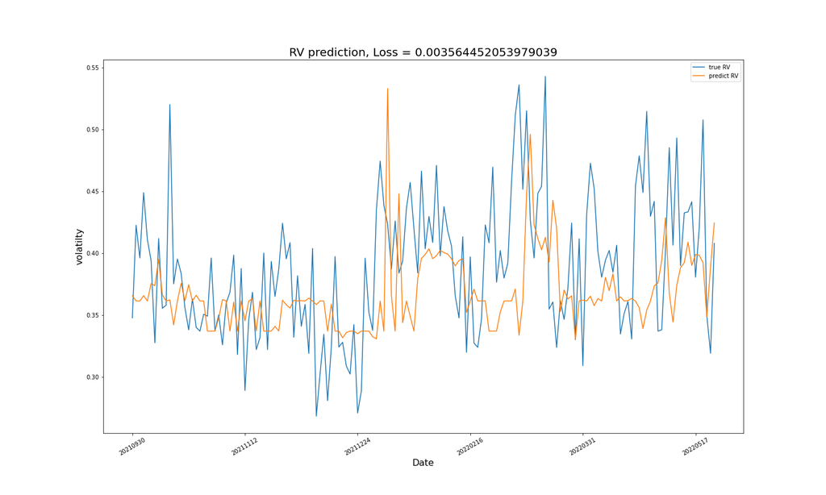

## Project目標：檢定採用`隱含波動度`做為額外資訊輸入，能否提升對`預測`台股大盤指數未來報酬波動度的`精確度`

### 動機：

報酬波動度預測在財務金融領域中一直是熱門主題，波動度代表著風險，也是風險資產中最重要的性質。時間序列資料有著強烈的自相關性，故拿過往的歷史報酬波動度(又稱實際波動度 Realized Volatility，以下簡稱RV)去對未來的報酬波動度做預測是非常直覺的，因此主流學術研究皆以RV作為輸入資料，著重以模型的優化來提升報酬波動度的預測能力。  
然而與未來報酬波動度相關的資訊還有隱含波動度(Implied Volatility，以下簡稱IV)，這一個由BS歐式選擇權定價模型所反向推導的資訊，理論上IV可以被視為市場對於**與選擇權掛勾的標的物**，在選擇權的**權利期間內**的**報酬波動度的預測**。

> 我們有沒有辦法從IV中解讀到額外的資訊，來提升對未來報酬波動度的預測能力？？

### 輸入資料：

我們嘗試將**IV**的資訊作為額外的輸入資料，來對**台灣加權指數隔日的報酬波動度**做預測，並用**選擇權交易策略**來比較模型預測在實際交易上的損益表現。  
輸入資料的部分，我們使用了`2016/1/4~2022/5/24`**台灣證券交易所提供的5秒台灣加權指數日內資料**，並還原除息對點數的影響，去計算每日的**RV**。  
至於**IV**的部分，我們採用**台灣證券交易所提供的選擇權日資料**，使用最近到期的選擇權**日盤買權收盤價**來進行IV的計算，並以交易量進行加權作為模型的額外輸入資料。

### 模型選擇：

在模型選擇方面，我們採用在時間序列上表現優異的**LSTM**，其架構的特點在於，在輸入資料進入模型的同時，還會同時輸入上一次模型的狀態，該狀態與上一筆所輸入的資料有相關，這使得LSTM可以處理序列相關的資料。除了深度學習的**LSTM**架構外，也採用**LSTM混合GARCH模型參數**的混合模型，許多論文研究認為用GARCH模型去做**特徵選擇**能夠使模型更快收斂，也有著更好的預測能力。我們將同時採用上述2種模型進行預測能力的比較。

### 實務影響：

單純使用RV+LSTM的模型無論在樣本外的表現能力或是交易策略的勝率皆是最優秀的，而單日的IV加權與混合GARCH參數皆無法提升樣本外的預測表現。故在RV+LSTM模型預測明日有劇烈波動時，可以考慮採行波動率策略來賺取報酬。

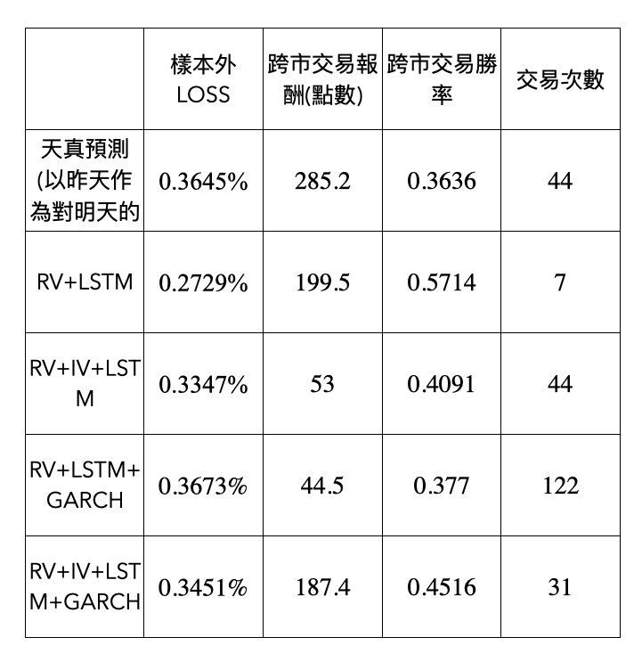

研究結果

結論上**隱含波動度**並無法提升對於未來報酬波動度的，但主要原因推測為選擇權的IV與選擇權價格是具有一對一關係的，然而礙於期交所只有提供日資料，而選擇權價格單日變動非常劇烈，單一時間點的資訊可能無法對預測提供有用的幫助。  
雖然有些氣餒，但這一路的過程，從**網路爬蟲&API呼叫**取得資料與**database的存取(sqlite3)**、**資料的轉換處理與視覺化(pandas, matlibplot)** 以及**深度學習模型的架設(pytorch)**，後續的連結也詳細紀錄了我是如何一步一步完成整個project。

## Project各章的內容與連結

- Part 1: [**資料處理**] 從台灣證券交易所、期貨交易所跟央行取得台股大盤5秒日內資料、台股選擇權日資料與隔夜拆款利率，並將其儲存在db中
- Part 2: [**資料處理**] 用台股大盤5秒日內資料計算RV，用央行隔夜拆款、大盤收盤、選擇權權利期間、選擇權履約價跟選擇權收盤價來估算IV，並進行驗證
- Part 3: [**資料視覺化**] 將每日的RV與IV加權做資料視覺化，檢視在極端形況下兩者的關聯性
- Part 4: [**深度學習模型訓練**] 架設LSTM模型，用RV跟RV+IV作為輸入資料進行訓練，並檢視在樣本外預測的表現
- Part 5: [**時間序列模型**] 用AR跟GARCH來進行波動度預測，並擷取GARCH(1,1)的參數，用以後面混合模型
- Part 6: [**深度學習模型訓練**] 用Part 4 架好的LSTM模型，用RV+GARCH參數跟RV+IV+GARCH參數作為輸入資料進行訓練，並檢視在樣本外預測的表現
- Part 7: [**交易策略**] 用跨式交易策略(波動性策略)來檢視這4種類的預測結果，在實際交易上的表現如何

### [論文全文連結](http://etds.lib.nchu.edu.tw/thesis/detail/10e7c801bf6ff327ab782bb24025b071/)